# Tips and Tricks with Jupyter Notebooks

## Part 4: Creating Interactive dashboards

Building interactive dashboards in Jupyter Notebooks can potentially be a long and complicated process.

Interactive dashboards in Jupyter won't work if you export them as static html files

*Top Tip: Understand your requirements*

Should you need to visualize your data with minimal data manipulation, it may be quicker to use data visualization tools like [PowerBI](https://powerbi.microsoft.com/en-us/) or [Tableau](https://www.tableau.com/).

- Ultimately, it would use less coding!

*Consider some Cloud solutions :)*

Working with Jupyter, we may want to share our dashboards, but interactive forms of notebooks are not easily shareable.

[dataschool.io](https://www.dataschool.io/cloud-services-for-jupyter-notebook/) evaluates some cloud notebook tools with a breakdown of their considerations:

- Supported Languages
- Ability to install packages
- Interface similarity
- Sharing publicly
- Ability to collaborate

Example technologies:

- [Binder](https://mybinder.org/)
- [Kaggle Kernels](https://www.kaggle.com/)
- [Google Colab](https://colab.research.google.com/notebooks/intro.ipynb#recent=true)
- [Microsoft Azure notebooks](https://notebooks.azure.com/#)
- [Databricks](https://databricks.com/)
- [EC2 hosted Jupyter Notebook instance on virtual machine](https://dzone.com/articles/running-your-jupyter-notebooks-on-the-cloud)

### Typical libraries for Jupyter Dashboards

- [Pandas](https://pandas.pydata.org/), Numpy
- [SciKit-Learn](https://scikit-learn.org/stable/index.html) - Machine Learning
- [Matplotlib](https://matplotlib.org/), [Seaborn](http://seaborn.pydata.org/), [Plotly](https://plotly.com/) - data visualization
- [ipywidgets](https://ipywidgets.readthedocs.io/en/stable/examples/Widget%20List.html) e.g. for dropdowns, sliders etc.

### Dashboard example: Google Analytics Linear Regression Project

My [linear regression project](https://github.com/Kremzeeq/ga_linear_regression_project) presents some web traffic data in an interactive dashboard.

This is split into two sections:

**Section A**

- Shows Graphical representation for Linear Model based on training data using Seaborn.
- Predictor box provided so the number of Users can be entered to predict Sessions and Page Views.

**Section B**

- Provides an overview on web metrics, built using plotly which offers interactive elements for graphs beyond dropdown ipywidgets

This can been constructed with classes for controllers and views

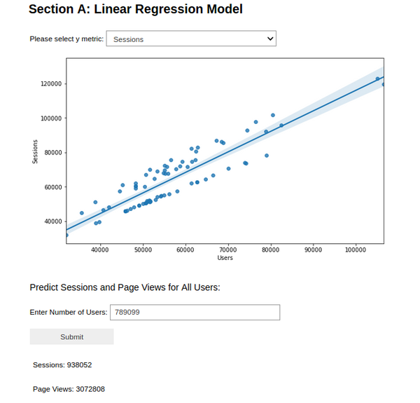

```python
from image_renderer import image_renderer
image_renderer(basewidth=600,image_path='../assets/dashboard_section_a.png')
```

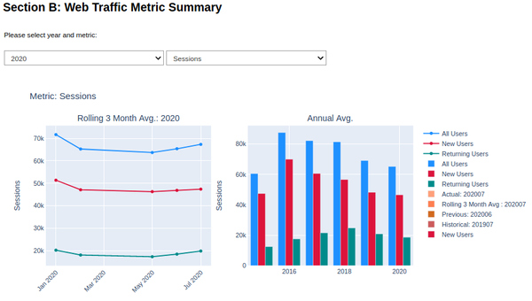

```python
image_renderer(basewidth=600,image_path='../assets/dashboard_section_b_p1.png')
```

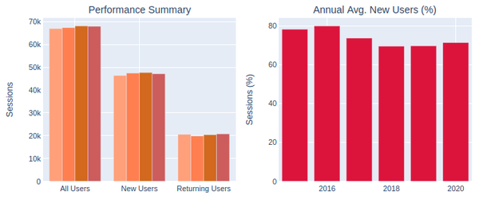

```python
image_renderer(basewidth=600,image_path='../assets/dashboard_section_b_p2.png')
```

### Accessing an interactive version of the dashboard

Here's the [jupyter notebook](https://github.com/Kremzeeq/ga_linear_regression_project/blob/master/jupyter_notebooks/GA_Linear_Regression_Analysis_P4-Dashboarding.ipynb) with source code for reproducing the dashboard.

This has taken inspiration from having previously produced web traffic dashboards in excel in a former life :)

Running all the cells shows the widgets as shown in screenshots above.

It's possible to access the notebook online, on Kaggle, however, this proved to be more complicated than one would like!!

### Steps for Accessing the Dashboard on Kaggle

1. Click this link: https://www.kaggle.com/kremzeeq/ga-linear-regression-analysis-dashboarding/edit
2. Click the blue Copy and Edit button
3. You have a Kaggle account, you can login and upload the GA_web_traffic_data_12_08_20.csv file.
4. Next, you should be able to click 'Run All' for the notebook with the dashboard and interact with notebook widgets.

Thanks for making it this far :)

### Finally, if you like this resource, please give a star to the Jupyter Notebooks Tips and Tricks [GitHub project](https://github.com/Kremzeeq/jupyter_notebooks_tips_and_tricks)!

```python
%%html
<style type="text/css">
div.jp-InputArea {
    display:none;
}
div.input {
    display:none;
}
</style>
```